# EasyVisa Project

# Model evaluation criterion

#### Model can make wrong predictions as:

Model predicts that the visa application will get certified but in reality, the visa application should get denied. Model predicts that the visa application will not get certified but in reality, the visa application should get certified.

#### Which case is more important?

#### Both the cases are important as:

If a visa is certified when it had to be denied a wrong employee will get the job position while US citizens will miss the opportunity to work on that position.

If a visa is denied when it had to be certified the U.S. will lose a suitable human resource that can contribute to the economy.

#### How to reduce the losses?

F1 Score can be used a the metric for evaluation of the model, greater the F1 score higher are the chances of minimizing False Negatives and False Positives. We will use balanced class weights so that model focuses equally on both classes.

#### First, let's create functions to calculate different metrics and confusion matrix so that we don't have to use the same code repeatedly for each model.

The model_performance_classification_sklearn function will be used to check the model performance of models. The confusion_matrix_sklearn function will be used to plot the confusion matrix.

```python
# defining a function to compute different metrics to check performance of a classification model built using sklearn


def model_performance_classification_sklearn(model, predictors, target):
    """
    Function to compute different metrics to check classification model performance

    model: classifier
    predictors: independent variables
    target: dependent variable
    """

    # predicting using the independent variables
    pred = model.predict(predictors)

    acc = accuracy_score(target, pred)  # to compute Accuracy
    recall = recall_score(target, pred)  # to compute Recall
    precision = precision_score(target, pred)  # to compute Precision
    f1 = f1_score(target, pred)  # to compute F1-score

    # creating a dataframe of metrics
    df_perf = pd.DataFrame(
        {"Accuracy": acc, "Recall": recall, "Precision": precision, "F1": f1,},
        index=[0],
    )

    return df_perf
```

```python
def confusion_matrix_sklearn(model, predictors, target):
    """
    To plot the confusion_matrix with percentages

    model: classifier
    predictors: independent variables
    target: dependent variable
    """
    y_pred = model.predict(predictors)
    cm = confusion_matrix(target, y_pred)
    labels = np.asarray(
        [
            ["{0:0.0f}".format(item) + "\n{0:.2%}".format(item / cm.flatten().sum())]
            for item in cm.flatten()
        ]
    ).reshape(2, 2)

    plt.figure(figsize=(6, 4))
    sns.heatmap(cm, annot=labels, fmt="")
    plt.ylabel("True label")
    plt.xlabel("Predicted label")
```

### Decision Tree Model

```python
dtree=DecisionTreeClassifier(random_state=1)
dtree.fit(X_train,y_train)
```

```
DecisionTreeClassifier(random_state=1)
```

### Checking model performance on training set

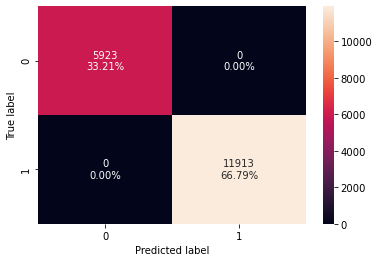

```python
# confusion matrix for train data
confusion_matrix_sklearn(dtree, X_train, y_train)
```

```python
## Let's check the performance on train data
decision_tree_perf_train = model_performance_classification_sklearn(dtree, X_train, y_train)
decision_tree_perf_train
```

|  | Accuracy | Recall | Precision | F1 |
| --- | --- | --- | --- | --- |
| 0 | 1.0 | 1.0 | 1.0 | 1.0 |

### Observation:

- As, expected the decision tree grew upto it max limit clasiifying each data point.
- The model fits perefectly well on training data without any errors.

### Checking model performance on test set

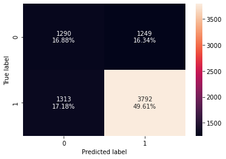

```python
## Let's create confusion matrix for test data
confusion_matrix_sklearn(dtree,X_test,y_test)
```

```python
# lets check for model performance
decision_tree_perf_test = model_performance_classification_sklearn(dtree, X_test, y_test)
decision_tree_perf_test
```

|  | Accuracy | Recall | Precision | F1 |
| --- | --- | --- | --- | --- |
| 0 | 0.664835 | 0.742801 | 0.752232 | 0.747487 |

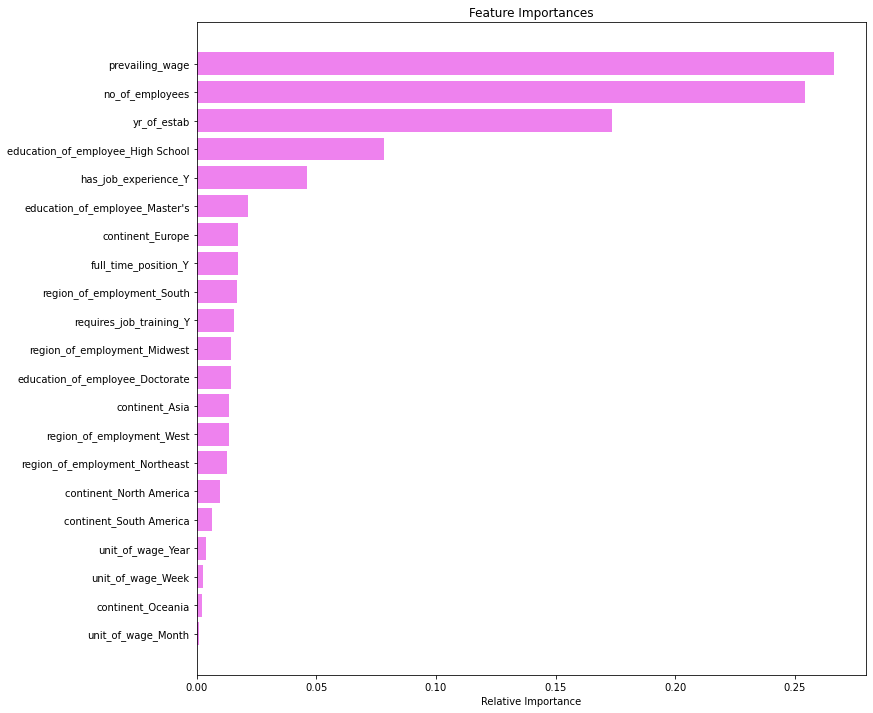

```python
feature_names = X_train.columns
importances = dtree.feature_importances_
indices = np.argsort(importances)

plt.figure(figsize=(12,12))
plt.title('Feature Importances')
plt.barh(range(len(indices)), importances[indices], color='violet', align='center')
plt.yticks(range(len(indices)), [feature_names[i] for i in indices])
plt.xlabel('Relative Importance')
plt.show()
```

### Observation :

- The scores do not look great.
- FN and FP can be further improved.
- There is more scope of generalizing the scores.
- prevailing wage and no of employees are some of the important features according to the model.

### Hyperparameter Tuning - Decision Tree

```python
import time
```

```python
# Choose the type of classifier.
dtree_estimator = DecisionTreeClassifier(class_weight="balanced", random_state=1)

# Grid of parameters to choose from
parameters = {
    "max_depth": np.arange(5, 16, 5),
    "min_samples_leaf": [3, 5, 7],
    "max_leaf_nodes": [2, 5],
    "min_impurity_decrease": [0.0001, 0.001],
}

# Type of scoring used to compare parameter combinations
scorer = metrics.make_scorer(metrics.f1_score)

# Run the grid search
grid_obj = GridSearchCV(dtree_estimator,parameters,scoring=scorer,n_jobs=-1)
start_time= time.time()
grid_obj = grid_obj.fit(X_train, y_train)
end_time = time.time()

dt_time = end_time-start_time
print("Time taken run the grid search:", dt_time)
# Set the clf to the best combination of parameters
dtree_estimator = grid_obj.best_estimator_

# Fit the best algorithm to the data.
dtree_estimator.fit(X_train, y_train)
```

```
Time taken run the grid search: 2.3801491260528564
```

```
DecisionTreeClassifier(class_weight='balanced', max_depth=5, max_leaf_nodes=2,
                       min_impurity_decrease=0.0001, min_samples_leaf=3,
                       random_state=1)
```

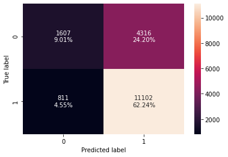

```python
# lets check confusion matrix  for the dtree_estimator on the train data

confusion_matrix_sklearn(dtree_estimator,X_train, y_train)
```

```python
# # lets check for model performance

dtree_estimator_model_train_perf = model_performance_classification_sklearn(dtree_estimator,X_train,y_train)
dtree_estimator_model_train_perf
```

|  | Accuracy | Recall | Precision | F1 |
| --- | --- | --- | --- | --- |
| 0 | 0.712548 | 0.931923 | 0.720067 | 0.812411 |

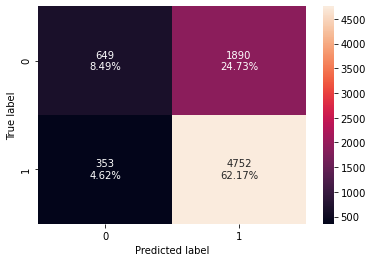

```python
# lets not check the confusion matrix on the test data

confusion_matrix_sklearn(dtree_estimator,X_test,y_test)
```

```python
# Lets now check the model performance on test data

dtree_estimator_model_test_perf = model_performance_classification_sklearn(dtree_estimator,X_test,y_test)
dtree_estimator_model_test_perf
```

|  | Accuracy | Recall | Precision | F1 |
| --- | --- | --- | --- | --- |
| 0 | 0.706567 | 0.930852 | 0.715447 | 0.809058 |

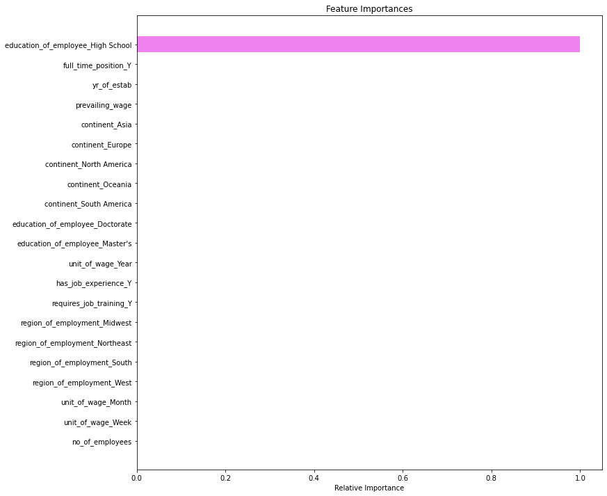

```python
feature_names = X_train.columns
importances = dtree_estimator.feature_importances_
indices = np.argsort(importances)

plt.figure(figsize=(12,12))
plt.title('Feature Importances')
plt.barh(range(len(indices)), importances[indices], color='violet', align='center')
plt.yticks(range(len(indices)), [feature_names[i] for i in indices])
plt.xlabel('Relative Importance')
plt.show()
```

### Observation :

- The scores are more generalized now.
- The scores on the test data is very close to the train data.
- F1 score on the test data is 0.809058 and the on the train data is 0.812411
- It can be a good model.
- Education is an important feature according to the model.

## Building bagging and boosting models

### Bagging Classifier

```python
# bagging classifier with random state = 1
bagging_classifier = BaggingClassifier(random_state = 1)
# lets fit a bagging model on train data
bagging_classifier.fit(X_train,y_train)
```

```
BaggingClassifier(random_state=1)
```

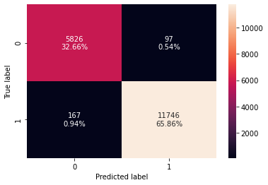

```python
# lets check the confusion matrix of the Bagging classifier on the train data

confusion_matrix_sklearn(bagging_classifier,X_train,y_train)
```

```python
# lets the model perfomance scores
bagging_classifier_model_train_perf= model_performance_classification_sklearn(bagging_classifier,X_train,y_train)
bagging_classifier_model_train_perf
```

|  | Accuracy | Recall | Precision | F1 |
| --- | --- | --- | --- | --- |
| 0 | 0.985198 | 0.985982 | 0.99181 | 0.988887 |

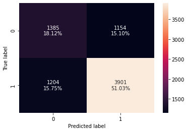

```python
# lets check the confusion matrix of the Bagging classifier on the test data
confusion_matrix_sklearn(bagging_classifier,X_test,y_test)
```

```python
# lets check the model performance scores on the test set
bagging_classifier_model_test_perf=model_performance_classification_sklearn(bagging_classifier,X_test,y_test)
bagging_classifier_model_test_perf
```

|  | Accuracy | Recall | Precision | F1 |
| --- | --- | --- | --- | --- |
| 0 | 0.691523 | 0.764153 | 0.771711 | 0.767913 |

### Hyperparameter Tuning - Bagging Classifier

```python
# Choose the type of classifier.
bagging_estimator_tuned = BaggingClassifier(random_state=1)

# Grid of parameters to choose from
parameters = {
    "max_samples": [0.7, 0.8, 0.9],
    "max_features": [0.7, 0.8, 0.9],
    "n_estimators": [90, 120, 10],
}

# Type of scoring used to compare parameter combinations
acc_scorer = metrics.make_scorer(metrics.f1_score)

## run grid search with cv=5
grid_obj = GridSearchCV(bagging_estimator_tuned, parameters, scoring=scorer,cv=5)

## Fit the grid_obj on train data
bag_start_time= time.time()
grid_obj = grid_obj.fit(X_train, y_train)
bag_end_time= time.time()
bag_total_time = bag_end_time-bag_start_time
print("Time taken run the grid search:", bag_total_time)

# Set the clf to the best combination of parameters
bagging_estimator_tuned = grid_obj.best_estimator_

# Fit the best algorithm to the data.
bagging_estimator_tuned.fit(X_train, y_train)
```

```
Time taken run the grid search: 458.09218549728394
```

```
BaggingClassifier(max_features=0.7, max_samples=0.7, n_estimators=120,
                  random_state=1)
```

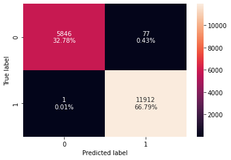

```python
# lets check the confusion matrix for the tuned bagged model on the train data
confusion_matrix_sklearn(bagging_estimator_tuned,X_train,y_train)
```

```python
# lets check the model performance scores of the tuned bagged model on the train data
bagging_estimator_tuned_model_train_perf= model_performance_classification_sklearn(bagging_estimator_tuned,X_train,y_train)
bagging_estimator_tuned_model_train_perf
```

|  | Accuracy | Recall | Precision | F1 |
| --- | --- | --- | --- | --- |
| 0 | 0.995627 | 0.999916 | 0.993577 | 0.996737 |

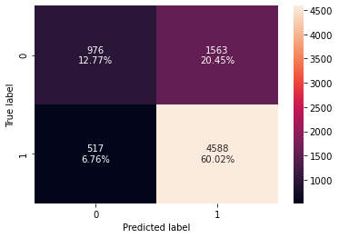

```python
# lets check the confusion matrix for the tuned bagged model on the test data
confusion_matrix_sklearn(bagging_estimator_tuned,X_test,y_test)
```

```python
# lets check the model performance scores of the tuned bagged model on the train data
bagging_estimator_tuned_model_test_perf= model_performance_classification_sklearn(bagging_estimator_tuned,X_test,y_test)
bagging_estimator_tuned_model_test_perf
```

|  | Accuracy | Recall | Precision | F1 |
| --- | --- | --- | --- | --- |
| 0 | 0.727891 | 0.898727 | 0.745895 | 0.81521 |

### Observation:

- The model is surely overfitting on the train data.
- The Test model perfoms well in the bagging tuned model than bagging classifier

### Random Forest

```python
# defining random forest with random state = 1 and class_weight = balanced
rf_estimator= RandomForestClassifier(random_state=1, class_weight = "balanced")
#lets fit the model
rf_estimator.fit(X_train,y_train)
```

```
RandomForestClassifier(class_weight='balanced', random_state=1)
```

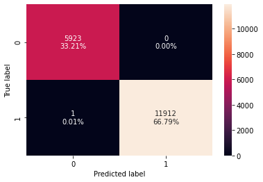

```python
# checking the confusion matrix of rf_est model on the train data
confusion_matrix_sklearn(rf_estimator,X_train,y_train)
```

```python
# lets check the model performance of the rf_est model on the train data
rf_estimator_model_train_perf= model_performance_classification_sklearn(rf_estimator,X_train,y_train)
rf_estimator_model_train_perf
```

|  | Accuracy | Recall | Precision | F1 |
| --- | --- | --- | --- | --- |
| 0 | 0.999944 | 0.999916 | 1.0 | 0.999958 |

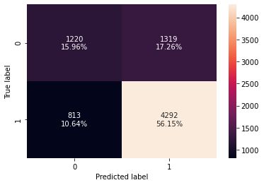

```python
# checking the confusion matrix of rf_est model on the test data
confusion_matrix_sklearn(rf_estimator,X_test,y_test)
```

```python
# checking the confusion matrix of rf_est model on the test data
rf_estimator_model_test_perf= model_performance_classification_sklearn(rf_estimator,X_test,y_test)
rf_estimator_model_test_perf
```

|  | Accuracy | Recall | Precision | F1 |
| --- | --- | --- | --- | --- |
| 0 | 0.721088 | 0.840744 | 0.764926 | 0.801045 |

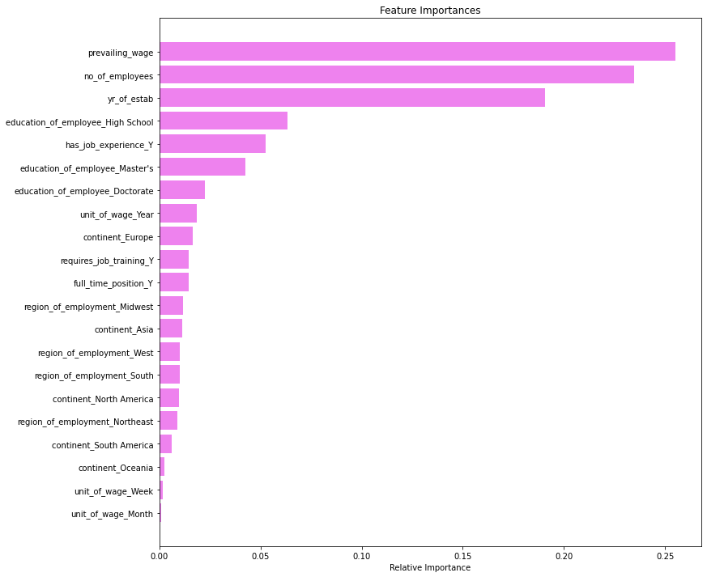

```python
feature_names = X_train.columns
importances = rf_estimator.feature_importances_
indices = np.argsort(importances)

plt.figure(figsize=(12,12))
plt.title('Feature Importances')
plt.barh(range(len(indices)), importances[indices], color='violet', align='center')
plt.yticks(range(len(indices)), [feature_names[i] for i in indices])
plt.xlabel('Relative Importance')
plt.show()
```

### Observation:

- It is overfitting on the train data.
- Scores of the test data are not close to train data.
- previaling wage and no of employess are some important features according to this model.

### Hyperparameter Tuning - Random Forest

```python
# Choose the type of classifier.
rf_tuned = RandomForestClassifier(random_state=1, oob_score=True, bootstrap=True)

parameters = {
    "max_depth": list(np.arange(5, 15, 5)),
    "max_features": ["sqrt", "log2"],
    "min_samples_split": [3, 5, 7],
    "n_estimators": [0, 40, 10],
}

# Type of scoring used to compare parameter combinations
acc_scorer = metrics.make_scorer(metrics.f1_score)

# Run the grid search
## Complete the code to run grid search with cv = 5 and n_jobs = -1
grid_start_time= time.time()
grid_obj = GridSearchCV(rf_tuned, parameters, scoring=scorer, cv=5,n_jobs=-1)
grid_end_time= time.time()

grid_total_time = grid_end_time-grid_start_time
print("Time taken to run the grid search:", grid_total_time)

## Complete the code to fit the grid_obj on the train data
grid_obj = grid_obj.fit(X_train, y_train)

# Set the clf to the best combination of parameters
rf_tuned = grid_obj.best_estimator_

# Fit the best algorithm to the data.
rf_tuned.fit(X_train, y_train)
```

```
Time taken to run the grid search: 0.0
```

```
RandomForestClassifier(max_depth=10, max_features='sqrt', min_samples_split=3,
                       n_estimators=40, oob_score=True, random_state=1)
```

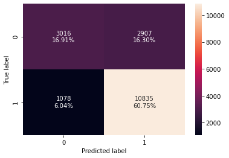

```python
# checking the confusion matrix of tuned_rf_est model on the train data
confusion_matrix_sklearn(rf_tuned,X_train,y_train)
```

```python
# lets check the model performance of the tuned_rf_est model on the train data
rf_tuned_model_train_perf= model_performance_classification_sklearn(rf_tuned,X_train,y_train)
rf_tuned_model_train_perf
```

|  | Accuracy | Recall | Precision | F1 |
| --- | --- | --- | --- | --- |
| 0 | 0.776575 | 0.909511 | 0.788459 | 0.84467 |

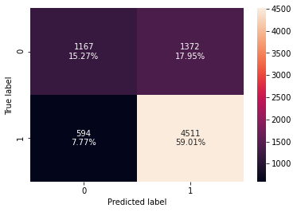

```python
# checking the confusion matrix of tuned_rf_est model on the test data
confusion_matrix_sklearn(rf_tuned,X_test,y_test)
```

```python
# checking the confusion matrix of tuned_rf_est model on the test data
rf_tuned_model_test_perf=model_performance_classification_sklearn(rf_tuned,X_test,y_test)
rf_tuned_model_test_perf
```

|  | Accuracy | Recall | Precision | F1 |
| --- | --- | --- | --- | --- |
| 0 | 0.742805 | 0.883643 | 0.766786 | 0.821078 |

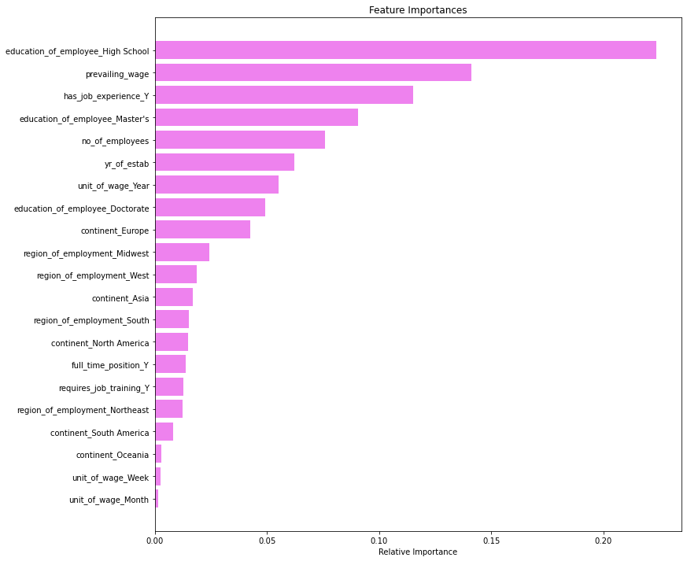

```python
feature_names = X_train.columns
importances = rf_tuned.feature_importances_
indices = np.argsort(importances)

plt.figure(figsize=(12,12))
plt.title('Feature Importances')
plt.barh(range(len(indices)), importances[indices], color='violet', align='center')
plt.yticks(range(len(indices)), [feature_names[i] for i in indices])
plt.xlabel('Relative Importance')
plt.show()
```

### Observation :

- The hyper tuned moded gives really good scores.
- F1 score on test data is very close to the train data.
- Over all a good model.
- Education and previaling wage are some important features according to this model.

### AdaBoost Classifier

```python
##  defining AdaBoost Classifier with random state = 1
ab_classifier = AdaBoostClassifier(random_state=1)
## Let's fit AdaBoost Classifier on the train data
ab_classifier.fit(X_train,y_train)
```

```
AdaBoostClassifier(random_state=1)
```

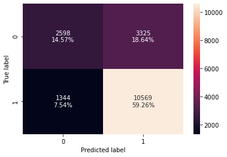

```python
# checking the confusion matrix of adaboost model on the train data
confusion_matrix_sklearn(ab_classifier,X_train,y_train)
```

```python
# lets check the model performance of the adaboost model on the train data
ab_classifier_model_train_perf = model_performance_classification_sklearn(ab_classifier,X_train,y_train)
ab_classifier_model_train_perf
```

|  | Accuracy | Recall | Precision | F1 |
| --- | --- | --- | --- | --- |
| 0 | 0.738226 | 0.887182 | 0.760688 | 0.81908 |

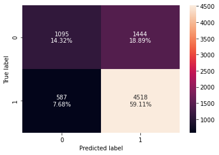

```python
# checking the confusion matrix of adaboost model on the test data
confusion_matrix_sklearn(ab_classifier,X_test,y_test)
```

```python
# lets check the model performance of the adaboost model on the test data
ab_classifier_model_test_perf = model_performance_classification_sklearn(ab_classifier,X_test,y_test)
ab_classifier_model_test_perf
```

|  | Accuracy | Recall | Precision | F1 |
| --- | --- | --- | --- | --- |
| 0 | 0.734301 | 0.885015 | 0.757799 | 0.816481 |

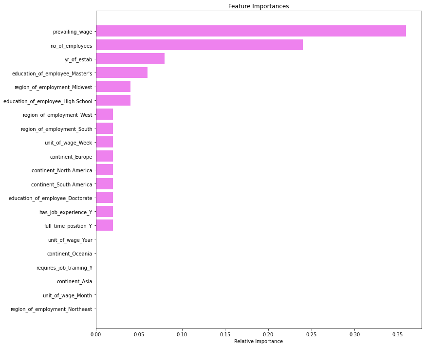

```python
feature_names = X_train.columns
importances = ab_classifier.feature_importances_
indices = np.argsort(importances)

plt.figure(figsize=(12,12))
plt.title('Feature Importances')
plt.barh(range(len(indices)), importances[indices], color='violet', align='center')
plt.yticks(range(len(indices)), [feature_names[i] for i in indices])
plt.xlabel('Relative Importance')
plt.show()
```

### Observation :

- The model performs well on train and test data.
- The performance scores on both train and test are very close.
- Really good scores and a very good model.
- previaling wage and no of employees are some important features according to this model.

### Hypertuning - AdaBoost Classifier

```python
# Choose the type of classifier.
abc_tuned = AdaBoostClassifier(random_state=1)

# Grid of parameters to choose from
parameters = {
    # Let's try different max_depth for base_estimator
    "base_estimator": [
        DecisionTreeClassifier(max_depth=1, class_weight="balanced", random_state=1),
        DecisionTreeClassifier(max_depth=2, class_weight="balanced", random_state=1),
        DecisionTreeClassifier(max_depth=3, class_weight="balanced", random_state=1),
    ],
    "n_estimators": [60, 100, 10],
    "learning_rate": [0.1, 0.4, 0.1],
}

# Type of scoring used to compare parameter  combinations
acc_scorer = metrics.make_scorer(metrics.f1_score)

# Run the grid search
## Complete the code to run grid search with cv = 5
grid_obj = GridSearchCV(abc_tuned, parameters, scoring=scorer,cv=5)

## Complete the code to fit the grid_obj on train data

ada_start_time = time.time()
grid_obj = grid_obj.fit(X_train, y_train)
ada_end_time = time.time()

ada_total_time = ada_end_time-ada_start_time
print("Time taken run the grid search:", ada_total_time)

# Set the clf to the best combination of parameters
abc_tuned = grid_obj.best_estimator_

# Fit the best algorithm to the data.
abc_tuned.fit(X_train, y_train)
```

```
Time taken run the grid search: 164.24202370643616
```

```
AdaBoostClassifier(base_estimator=DecisionTreeClassifier(class_weight='balanced',
                                                         max_depth=1,
                                                         random_state=1),
                   learning_rate=0.1, n_estimators=10, random_state=1)
```

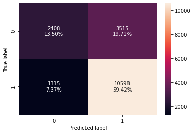

```python
# checking the confusion matrix of tuned adaboost model on the train data
confusion_matrix_sklearn(abc_tuned,X_train,y_train)
```

```python
# lets check the model performance of the tunedadaboost model on the train data
abc_tuned_model_train_perf=model_performance_classification_sklearn(abc_tuned,X_train,y_train)
abc_tuned_model_train_perf
```

|  | Accuracy | Recall | Precision | F1 |
| --- | --- | --- | --- | --- |
| 0 | 0.729199 | 0.889616 | 0.750939 | 0.814416 |

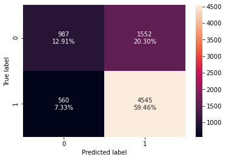

```python
# checking the confusion matrix of tuned adaboost model on the test data
confusion_matrix_sklearn(abc_tuned,X_test,y_test)
```

```python
# lets check the model performance of the tunedadaboost model on the test data
abc_tuned_model_test_perf=model_performance_classification_sklearn(abc_tuned,X_test,y_test)
abc_tuned_model_test_perf
```

|  | Accuracy | Recall | Precision | F1 |
| --- | --- | --- | --- | --- |
| 0 | 0.723705 | 0.890304 | 0.745449 | 0.811462 |

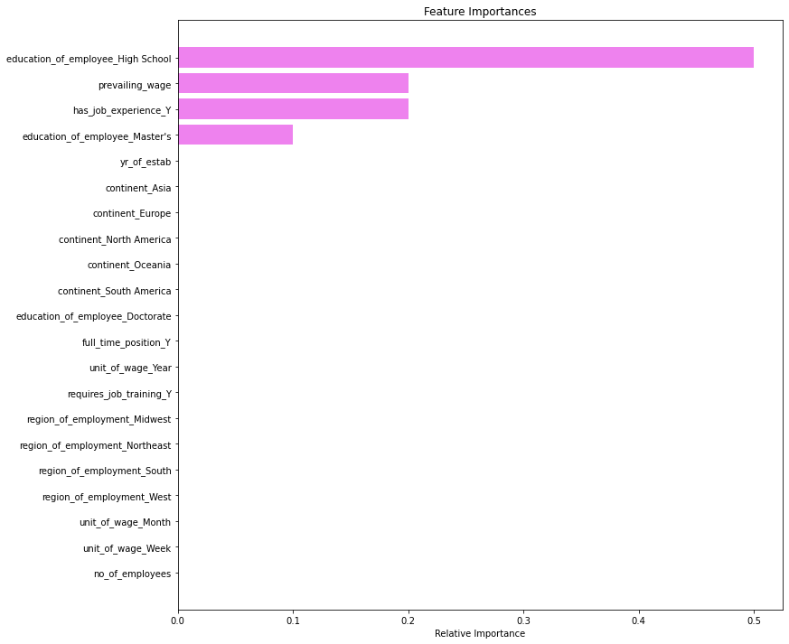

```python
feature_names = X_train.columns
importances = abc_tuned.feature_importances_
indices = np.argsort(importances)

plt.figure(figsize=(12,12))
plt.title('Feature Importances')
plt.barh(range(len(indices)), importances[indices], color='violet', align='center')
plt.yticks(range(len(indices)), [feature_names[i] for i in indices])
plt.xlabel('Relative Importance')
plt.show()
```

### Observation:

- Model performs well on both train and test data.
- model performance scores are genralized and very close when compared.
- F1 scores are almost the same
- Education and previaliing wage are some important features according to this model.

### Gradient Boosting Classifier

```python
# defining Gradient Boosting Classifier with random state = 1
gb_classifier = GradientBoostingClassifier(random_state=1)

## Let's fit Gradient Boosting Classifier on the train data
gb_classifier.fit(X_train,y_train)
```

```
GradientBoostingClassifier(random_state=1)
```

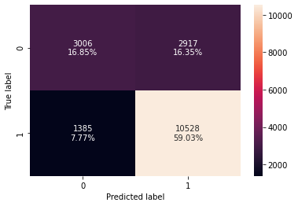

```python
# checking the confusion matrix of GradientBoost model on the train data
confusion_matrix_sklearn(gb_classifier,X_train,y_train)
```

```python
# lets check the model performance of the GradientBoost  model on the train data
gb_classifier_model_train_perf=model_performance_classification_sklearn(gb_classifier,X_train,y_train)
gb_classifier_model_train_perf
```

|  | Accuracy | Recall | Precision | F1 |
| --- | --- | --- | --- | --- |
| 0 | 0.758802 | 0.88374 | 0.783042 | 0.830349 |

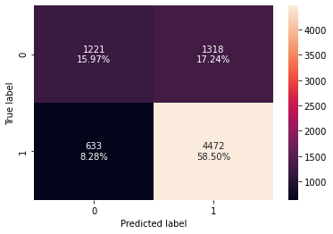

```python
# checking the confusion matrix of GradientBoost model on the test data
confusion_matrix_sklearn(gb_classifier,X_test,y_test)
```

```python
# lets check the model performance of the GradientBoost model model on the test data
gb_classifier_model_test_perf=model_performance_classification_sklearn(gb_classifier,X_test,y_test)
gb_classifier_model_test_perf
```

|  | Accuracy | Recall | Precision | F1 |
| --- | --- | --- | --- | --- |
| 0 | 0.744767 | 0.876004 | 0.772366 | 0.820927 |

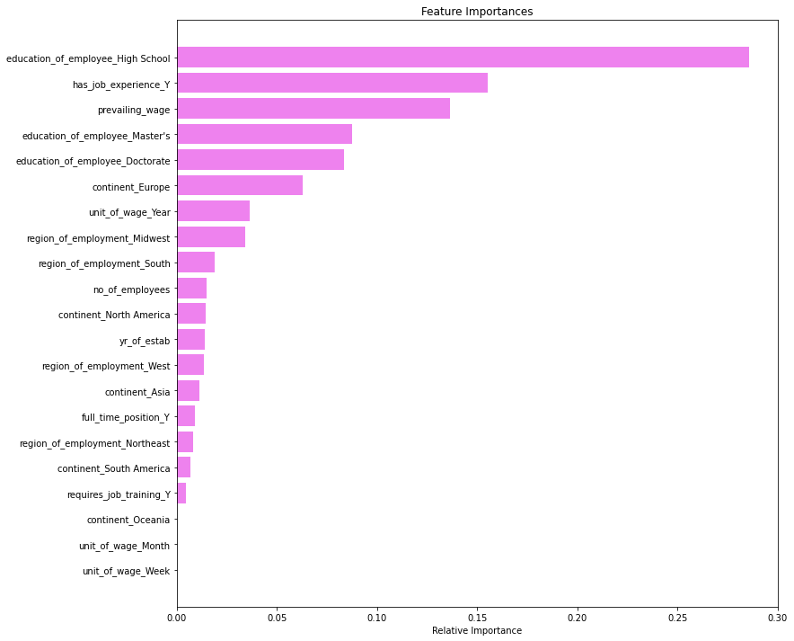

```python
feature_names = X_train.columns
importances = gb_classifier.feature_importances_
indices = np.argsort(importances)

plt.figure(figsize=(12,12))
plt.title('Feature Importances')
plt.barh(range(len(indices)), importances[indices], color='violet', align='center')
plt.yticks(range(len(indices)), [feature_names[i] for i in indices])
plt.xlabel('Relative Importance')
plt.show()
```

### Observation :

- Model performs well on train and test data
- Scores on the both train and test are very close.
- Education and Job Experience are some important features according to this model.

### Hyperparameter Tuning Gradient Boosting Classifier

```python
# Choose the type of classifier.
gbc_tuned = GradientBoostingClassifier(
    init=AdaBoostClassifier(random_state=1), random_state=1
)

# Grid of parameters to choose from
parameters = {
    "n_estimators": [100, 150],
    "subsample": [0.8, 0.9],
    "max_features": [0.8, 0.9, 1],
    "learning_rate": [0.1, 0.4],
}

# Type of scoring used to compare parameter combinations
acc_scorer = metrics.make_scorer(metrics.f1_score)

# Run the grid search
## Complete the code to run grid search with cv = 5
grid_obj = GridSearchCV(gbc_tuned, parameters, scoring=scorer,cv=5)

## Let's fit the grid_obj on train data

grad_start_time = time.time()
grid_obj = grid_obj.fit(X_train, y_train)
grad_end_time = time.time()

grad_total_time = grad_end_time-grad_start_time
print("Time taken run the grid search:", grad_total_time)

# Set the clf to the best combination of parameters
gbc_tuned = grid_obj.best_estimator_

# Fit the best algorithm to the data.
gbc_tuned.fit(X_train, y_train)
```

```
Time taken run the grid search: 262.20593190193176
```

```
GradientBoostingClassifier(init=AdaBoostClassifier(random_state=1),
                           max_features=0.9, random_state=1, subsample=0.9)
```

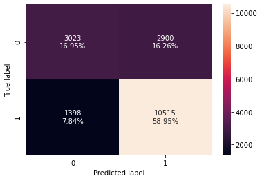

```python
# checking the confusion matrix of Tuned GradientBoost model on the train data
confusion_matrix_sklearn(gbc_tuned,X_train,y_train)
```

```python
# lets check the model performance of the Tuned GradientBoost model on the train data
gbc_tuned_model_train_perf = model_performance_classification_sklearn(gbc_tuned,X_train,y_train)
gbc_tuned_model_train_perf
```

|  | Accuracy | Recall | Precision | F1 |
| --- | --- | --- | --- | --- |
| 0 | 0.759027 | 0.882649 | 0.783824 | 0.830306 |

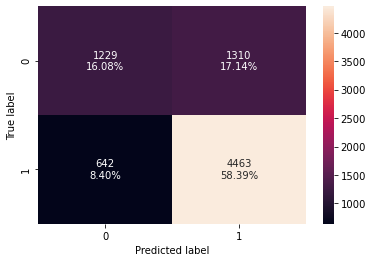

```python
# checking the confusion matrix of Tuned GradientBoost model on the test data
confusion_matrix_sklearn(gbc_tuned,X_test,y_test)
```

```python
# lets check the model performance of the Tuned GradientBoost model on the test data
gbc_tuned_model_test_perf = model_performance_classification_sklearn(gbc_tuned,X_test,y_test)
gbc_tuned_model_test_perf
```

|  | Accuracy | Recall | Precision | F1 |
| --- | --- | --- | --- | --- |
| 0 | 0.744636 | 0.874241 | 0.773082 | 0.820555 |

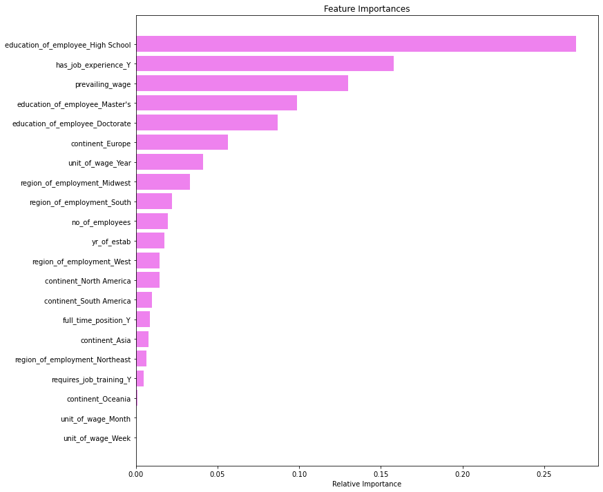

```python
feature_names = X_train.columns
importances = gbc_tuned.feature_importances_
indices = np.argsort(importances)

plt.figure(figsize=(12,12))
plt.title('Feature Importances')
plt.barh(range(len(indices)), importances[indices], color='violet', align='center')
plt.yticks(range(len(indices)), [feature_names[i] for i in indices])
plt.xlabel('Relative Importance')
plt.show()
```

### Observation :

- Model performs well on train and test data.
- Scores on the both train and test are very close.
- Both the gradient and Tuned gradient model performance scores are identical.
- Education and Job Experience are some important features according to this model.

### XGBoost Classifier

```python
#  defining XGBoost Classifier with random state = 1 and eval_metric="logloss"
xgb_classifier = XGBClassifier(random_state= 1,eval_metric="logloss")
xgb_classifier.fit(X_train,y_train)
```

```
XGBClassifier(base_score=0.5, booster='gbtree', colsample_bylevel=1,
              colsample_bynode=1, colsample_bytree=1, enable_categorical=False,
              eval_metric='logloss', gamma=0, gpu_id=-1, importance_type=None,
              interaction_constraints='', learning_rate=0.300000012,
              max_delta_step=0, max_depth=6, min_child_weight=1, missing=nan,
              monotone_constraints='()', n_estimators=100, n_jobs=4,
              num_parallel_tree=1, predictor='auto', random_state=1,
              reg_alpha=0, reg_lambda=1, scale_pos_weight=1, subsample=1,
              tree_method='exact', validate_parameters=1, verbosity=None)
```

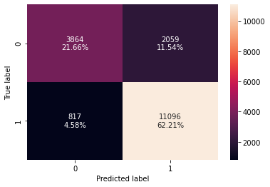

```python
# checking the confusion matrix of XGBoost model on the train data
confusion_matrix_sklearn(xgb_classifier,X_train,y_train)
```

```python
# lets check the model performance of the  XGBoost model on the train data
xgb_classifier_model_train_perf= model_performance_classification_sklearn(xgb_classifier,X_train,y_train)
xgb_classifier_model_train_perf
```

|  | Accuracy | Recall | Precision | F1 |
| --- | --- | --- | --- | --- |
| 0 | 0.838753 | 0.931419 | 0.843482 | 0.885272 |

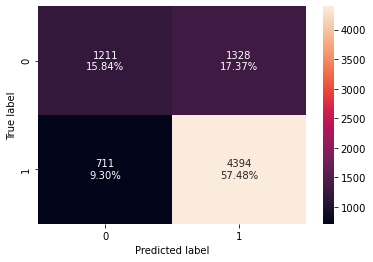

```python
# checking the confusion matrix of XGBoost model on the test data
confusion_matrix_sklearn(xgb_classifier,X_test,y_test)
```

```python
# lets check the model performance of the  XGBoost model on the test data
xgb_classifier_model_test_perf=model_performance_classification_sklearn(xgb_classifier,X_test,y_test)
xgb_classifier_model_test_perf
```

|  | Accuracy | Recall | Precision | F1 |
| --- | --- | --- | --- | --- |
| 0 | 0.733255 | 0.860725 | 0.767913 | 0.811675 |

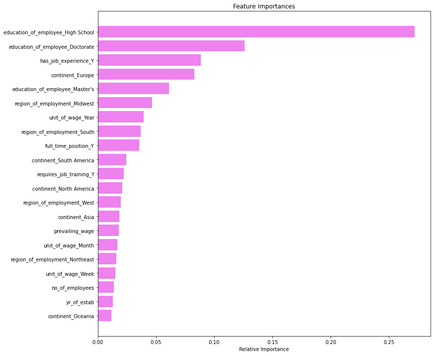

```python
feature_names = X_train.columns
importances = xgb_classifier.feature_importances_
indices = np.argsort(importances)

plt.figure(figsize=(12,12))
plt.title('Feature Importances')
plt.barh(range(len(indices)), importances[indices], color='violet', align='center')
plt.yticks(range(len(indices)), [feature_names[i] for i in indices])
plt.xlabel('Relative Importance')
plt.show()
```

### Observation :

- Model seems to be overfitting on the train data
- Scores do not look great when compared between train and test data.
- lets see if we can get generalized scored after tuning the model.
- Education and Job Experience are some important features according to this model.

### Hyperparameter Tuning - XGBoost Classifier

```python
# Choose the type of classifier.
xgb_tuned = XGBClassifier(random_state=1, eval_metric="logloss")

# Grid of parameters to choose from
parameters = {
    "n_estimators": np.arange(150, 250, 50),
    "scale_pos_weight": [1, 2],
    "subsample": [0.9, 1],
    "learning_rate": np.arange(0.1, 0.21, 0.1),
    "gamma": [3, 5],
    "colsample_bytree": [0.8, 0.9],
    "colsample_bylevel": [ 0.9, 1],
}

# Type of scoring used to compare parameter combinations
acc_scorer = metrics.make_scorer(metrics.f1_score)

# Run the grid search
grid_obj = GridSearchCV (xgb_tuned, parameters, scoring=scorer,cv=5)

# lets fit the model

xgb_start_time = time.time()
grid_obj = grid_obj.fit(X_train,y_train)
xgb_end_time = time.time()

xgb_total_time = xgb_end_time-xgb_start_time

print("Time taken run the grid search:", xgb_total_time)

# Set the clf to the best combination of parameters
xgb_tuned = grid_obj.best_estimator_

# Fit the best algorithm to the data.
xgb_tuned.fit(X_train, y_train)
```

```
Time taken run the grid search: 1487.5704910755157
```

```
XGBClassifier(base_score=0.5, booster='gbtree', colsample_bylevel=1,
              colsample_bynode=1, colsample_bytree=0.9,
              enable_categorical=False, eval_metric='logloss', gamma=5,
              gpu_id=-1, importance_type=None, interaction_constraints='',
              learning_rate=0.1, max_delta_step=0, max_depth=6,
              min_child_weight=1, missing=nan, monotone_constraints='()',
              n_estimators=200, n_jobs=4, num_parallel_tree=1, predictor='auto',
              random_state=1, reg_alpha=0, reg_lambda=1, scale_pos_weight=1,
              subsample=1, tree_method='exact', validate_parameters=1,
              verbosity=None)
```

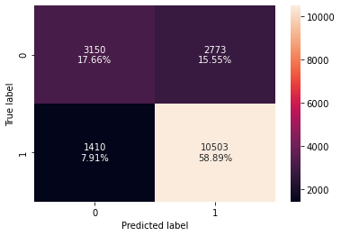

```python
# checking the confusion matrix of Tuned XGBoost model on the train data
confusion_matrix_sklearn(xgb_tuned,X_train,y_train)
```

```python
# lets check the model performance of the Tuned XGBoost model on the train data
xgb_tuned_model_train_perf = model_performance_classification_sklearn(xgb_tuned,X_train,y_train)
xgb_tuned_model_train_perf
```

|  | Accuracy | Recall | Precision | F1 |
| --- | --- | --- | --- | --- |
| 0 | 0.765474 | 0.881642 | 0.791127 | 0.833935 |

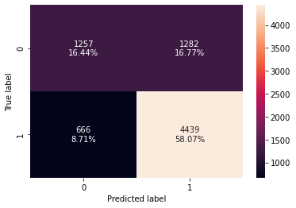

```python
# checking the confusion matrix of Tuned XGBoost model on the test data
confusion_matrix_sklearn(xgb_tuned,X_test,y_test)
```

```python
# lets check the model performance of the Tuned XGBoost model on the test data
xgb_tuned_model_test_perf= model_performance_classification_sklearn(xgb_tuned,X_test,y_test)
xgb_tuned_model_test_perf
```

|  | Accuracy | Recall | Precision | F1 |
| --- | --- | --- | --- | --- |
| 0 | 0.74516 | 0.86954 | 0.775913 | 0.820063 |

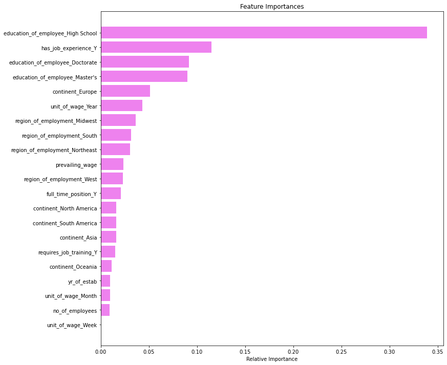

```python
feature_names = X_train.columns
importances = xgb_tuned.feature_importances_
indices = np.argsort(importances)

plt.figure(figsize=(12,12))
plt.title('Feature Importances')
plt.barh(range(len(indices)), importances[indices], color='violet', align='center')
plt.yticks(range(len(indices)), [feature_names[i] for i in indices])
plt.xlabel('Relative Importance')
plt.show()
```

### Observation:

- The model performs really well.
- model performs really well on train data and there isnt any overfitting.
- The scores are generalized and very close when comapared.
- Good recall score ad F1 score.
- Over all are very good model.
- Education and Job Experience are some important features according to this model.

### Stacking Classifier

```python
estimators = [
    ("AdaBoost", ab_classifier),
    ("Gradient Boosting", gbc_tuned),
    ("Random Forest", rf_tuned),
]

final_estimator = xgb_tuned

## Let's define Stacking Classifier
stacking_classifier = StackingClassifier(estimators=estimators,final_estimator=final_estimator)

## Let's fit Stacking Classifier on the train data
stacking_classifier.fit(X_train,y_train)
```

```
StackingClassifier(estimators=[('AdaBoost', AdaBoostClassifier(random_state=1)),
                               ('Gradient Boosting',
                                GradientBoostingClassifier(init=AdaBoostClassifier(random_state=1),
                                                           max_features=0.9,
                                                           random_state=1,
                                                           subsample=0.9)),
                               ('Random Forest',
                                RandomForestClassifier(max_depth=10,
                                                       max_features='sqrt',
                                                       min_samples_split=3,
                                                       n_estimators=40,
                                                       oob_score=True,
                                                       random_state=...
                                                 gpu_id=-1,
                                                 importance_type=None,
                                                 interaction_constraints='',
                                                 learning_rate=0.1,
                                                 max_delta_step=0, max_depth=6,
                                                 min_child_weight=1,
                                                 missing=nan,
                                                 monotone_constraints='()',
                                                 n_estimators=200, n_jobs=4,
                                                 num_parallel_tree=1,
                                                 predictor='auto',
                                                 random_state=1, reg_alpha=0,
                                                 reg_lambda=1,
                                                 scale_pos_weight=1,
                                                 subsample=1,
                                                 tree_method='exact',
                                                 validate_parameters=1,
                                                 verbosity=None))
```

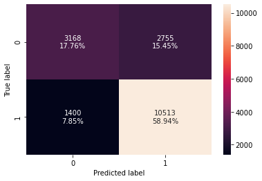

```python
# checking the confusion matrix of Stacking model on the train data
confusion_matrix_sklearn(stacking_classifier,X_train,y_train)
```

```python
# lets check the model performance of the Stacking model on the train data
stacking_classifier_model_train_perf = model_performance_classification_sklearn(stacking_classifier,X_train,y_train)
stacking_classifier_model_train_perf
```

|  | Accuracy | Recall | Precision | F1 |
| --- | --- | --- | --- | --- |
| 0 | 0.767044 | 0.882481 | 0.792358 | 0.834995 |

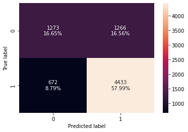

```python
# checking the confusion matrix of Stacking model on the test data
confusion_matrix_sklearn(stacking_classifier,X_test,y_test)
```

```python
# lets check the model performance of the Stacking model on the test data
stacking_classifier_model_test_perf = model_performance_classification_sklearn(stacking_classifier,X_test,y_test)
stacking_classifier_model_test_perf
```

|  | Accuracy | Recall | Precision | F1 |
| --- | --- | --- | --- | --- |
| 0 | 0.746468 | 0.868364 | 0.777856 | 0.820622 |

### Observation:

- Model performs well with generalized scored.
- Very identical to the Tuned XGboost model.
- Recall and F1 scores are similar to the XGboost model.

## Model Performance Comparison and Conclusions

```python
# training performance comparison

models_train_comp_df = pd.concat(
    [
        decision_tree_perf_train.T,
        dtree_estimator_model_train_perf.T,
        bagging_classifier_model_train_perf.T,
        bagging_estimator_tuned_model_train_perf.T,
        rf_estimator_model_train_perf.T,
        rf_tuned_model_train_perf.T,
        ab_classifier_model_train_perf.T,
        abc_tuned_model_train_perf.T,
        gb_classifier_model_train_perf.T,
        gbc_tuned_model_train_perf.T,
        xgb_classifier_model_train_perf.T,
        xgb_tuned_model_train_perf.T,
        stacking_classifier_model_train_perf.T,
    ],
    axis=1,
)
models_train_comp_df.columns = [
    "Decision Tree",
    "Tuned Decision Tree",
    "Bagging Classifier",
    "Tuned Bagging Classifier",
    "Random Forest",
    "Tuned Random Forest",
    "Adaboost Classifier",
    "Tuned Adaboost Classifier",
    "Gradient Boost Classifier",
    "Tuned Gradient Boost Classifier",
    "XGBoost Classifier",
    "XGBoost Classifier Tuned",
    "Stacking Classifier",
]
print("Training performance comparison:")
models_train_comp_df
```

```
Training performance comparison:
```

|  | Decision Tree | Tuned Decision Tree | Bagging Classifier | Tuned Bagging Classifier | Random Forest | Tuned Random Forest | Adaboost Classifier | Tuned Adaboost Classifier | Gradient Boost Classifier | Tuned Gradient Boost Classifier | XGBoost Classifier | XGBoost Classifier Tuned | Stacking Classifier |
| --- | --- | --- | --- | --- | --- | --- | --- | --- | --- | --- | --- | --- | --- |
| Accuracy | 1.0 | 0.712548 | 0.985198 | 0.995627 | 0.999944 | 0.776575 | 0.738226 | 0.729199 | 0.758802 | 0.759027 | 0.838753 | 0.765474 | 0.767044 |
| Recall | 1.0 | 0.931923 | 0.985982 | 0.999916 | 0.999916 | 0.909511 | 0.887182 | 0.889616 | 0.883740 | 0.882649 | 0.931419 | 0.881642 | 0.882481 |
| Precision | 1.0 | 0.720067 | 0.991810 | 0.993577 | 1.000000 | 0.788459 | 0.760688 | 0.750939 | 0.783042 | 0.783824 | 0.843482 | 0.791127 | 0.792358 |
| F1 | 1.0 | 0.812411 | 0.988887 | 0.996737 | 0.999958 | 0.844670 | 0.819080 | 0.814416 | 0.830349 | 0.830306 | 0.885272 | 0.833935 | 0.834995 |

```python
# checking the performance on the test data

# testing performance comparison
## Complete the code to check performance for test data
models_test_comp_df = pd.concat(
    [
        decision_tree_perf_test.T,
        dtree_estimator_model_test_perf.T,
        bagging_classifier_model_test_perf.T,
        bagging_estimator_tuned_model_test_perf.T,
        rf_estimator_model_test_perf.T,
        rf_tuned_model_test_perf.T,
        ab_classifier_model_test_perf.T,
        abc_tuned_model_test_perf.T,
        gb_classifier_model_test_perf.T,
        gbc_tuned_model_test_perf.T,
        xgb_classifier_model_test_perf.T,
        xgb_tuned_model_test_perf.T,
        stacking_classifier_model_test_perf.T,
    ],
    axis=1,
)
models_test_comp_df.columns = [
    "Test Decision Tree",
    "Test Tuned Decision Tree",
    "Test Bagging Classifier",
    "Test Tuned Bagging Classifier",
    "Test Random Forest",
    "Test Tuned Random Forest",
    "Test Adaboost Classifier",
    "Test Tuned Adaboost Classifier",
    "Test Gradient Boost Classifier",
    "Test Tuned Gradient Boost Classifier",
    "XGBoost Classifier",
    "XGBoost Classifier Tuned",
    "Test Stacking Classifier",
]
print("Test performance comparison:")
models_test_comp_df
```

```
Test performance comparison:
```

|  | Test Decision Tree | Test Tuned Decision Tree | Test Bagging Classifier | Test Tuned Bagging Classifier | Test Random Forest | Test Tuned Random Forest | Test Adaboost Classifier | Test Tuned Adaboost Classifier | Test Gradient Boost Classifier | Test Tuned Gradient Boost Classifier | XGBoost Classifier | XGBoost Classifier Tuned | Test Stacking Classifier |
| --- | --- | --- | --- | --- | --- | --- | --- | --- | --- | --- | --- | --- | --- |
| Accuracy | 0.664835 | 0.706567 | 0.691523 | 0.727891 | 0.721088 | 0.742805 | 0.734301 | 0.723705 | 0.744767 | 0.744636 | 0.733255 | 0.745160 | 0.746468 |
| Recall | 0.742801 | 0.930852 | 0.764153 | 0.898727 | 0.840744 | 0.883643 | 0.885015 | 0.890304 | 0.876004 | 0.874241 | 0.860725 | 0.869540 | 0.868364 |
| Precision | 0.752232 | 0.715447 | 0.771711 | 0.745895 | 0.764926 | 0.766786 | 0.757799 | 0.745449 | 0.772366 | 0.773082 | 0.767913 | 0.775913 | 0.777856 |
| F1 | 0.747487 | 0.809058 | 0.767913 | 0.815210 | 0.801045 | 0.821078 | 0.816481 | 0.811462 | 0.820927 | 0.820555 | 0.811675 | 0.820063 | 0.820622 |

### Obsevations considering the F1 score metric.

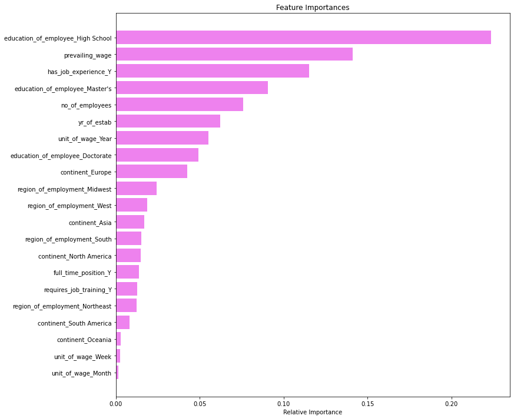

```python
### Important Features of the final and the best model Tuned Random Forest
feature_names = X_train.columns
importances = rf_tuned.feature_importances_
indices = np.argsort(importances)

plt.figure(figsize=(12, 12))
plt.title("Feature Importances")
plt.barh(range(len(indices)), importances[indices], color="violet", align="center")
plt.yticks(range(len(indices)), [feature_names[i] for i in indices])
plt.xlabel("Relative Importance")
plt.show()
```

### Observation:

- According our best model which is Tuned Random Forest with the F1 SCORE. Above chart and the below listed are the few important factors that affect the visa certification process.
- Starting with Education which is the prime factor for visa certification process.
- Prevailing wage also has a good importance for the visa certification process.
- Job Experience is another important factor for the visa certification process.
- Followed by the rest of the factors such as masters education and no of employees etc..

## Actionable Insights and Recommendations

## Insights and conclusions

### Below Insights are based on the EDA and the best Random Forest Tuned Model.

#### These insights can be applicable to both the Employer and the Applicant. Hence, categorizing the insights into Certification and Denial Criterea.

### According to the model and EDA, below are the few important factors to consider in order to Certify Visa.

- Education of the Employee - Applicants with Doctrate and Masters is highly preferred and the least Education level should be atleast a Bachelors degree.
- Prevailing wage - The Peak or median of the prevailing wage for the certified cases is very high in comaprison to the denied cases.
- Job Experience - It was very clear that the applicants with Job Experience have higher chances of visa getting certified.
- Unit wage - Yearly unit wage has higher chances of certified cases followed by week unit wage.
- continent - Europe has the highest number of certified visas followed by Africa.
- Region of Employment - Midwest Region followed by south and northeast has higher cases certified.

### According to the model and EDA, below are the few important factors to consider in order to Deny Visa.

- Education of the Employee - Applicants with High school Education has the highest chances of visa being denied.
- Prevailing wage - The Peak or median of the prevailing wage for the denied cases is very low when comapred to the certified cases.
- Job Experience - It was very clear that the applicants with no Job Experience have higher chances of visas getting Denied.
- Unit wage - Hourly unit wage has higher chances of visas getting Denied.
- continent - South America has the highest percentage of visas getting denied.
- Region of Employment - Island has the least cases that are certified.

### Other factors :

- Other factors such as Full time position and Requires job training is not highly considered atleast as per the model when it comes to visa certification process

## Recommendations

### Recommendations:

- It would have been appropriate to have more data such as Type of Job or specialization, Type of Education, Years of Experience , Age , Gender , Month and year the visa applied, location of the visa office.
- However, the data provided and the model gives a good idea as to what are basic requirements for the employer to look for before certifying a Visa.
- And, for the applicants to work on requirements needed to avoid their visa getting denied.